# MODULE 7 PROJECT ANN

### Let's create a function to plot confusion matrix and check model performance

```python
def make_confusion_matrix(
    cf,
    group_names=None,
    categories="auto",
    count=True,
    percent=True,
    cbar=True,
    xyticks=True,
    xyplotlabels=True,
    sum_stats=True,
    figsize=None,
    cmap="Blues",
    title=None,
):
    """
    This function will make a pretty plot of an sklearn Confusion Matrix cm using a Seaborn heatmap visualization.
    Arguments
    """

    # CODE TO GENERATE TEXT INSIDE EACH SQUARE
    blanks = ["" for i in range(cf.size)]

    if group_names and len(group_names) == cf.size:
        group_labels = ["{}\n".format(value) for value in group_names]
    else:
        group_labels = blanks

    if count:
        group_counts = ["{0:0.0f}\n".format(value) for value in cf.flatten()]
    else:
        group_counts = blanks

    if percent:
        group_percentages = [
            "{0:.2%}".format(value) for value in cf.flatten() / np.sum(cf)
        ]
    else:
        group_percentages = blanks

    box_labels = [
        f"{v1}{v2}{v3}".strip()
        for v1, v2, v3 in zip(group_labels, group_counts, group_percentages)
    ]
    box_labels = np.asarray(box_labels).reshape(cf.shape[0], cf.shape[1])

    # CODE TO GENERATE SUMMARY STATISTICS & TEXT FOR SUMMARY STATS
    if sum_stats:
        # Accuracy is sum of diagonal divided by total observations
        accuracy = np.trace(cf) / float(np.sum(cf))

        if len(cf) == 2:
            # Metrics for Binary Confusion Matrices
            precision = cf[1, 1] / sum(cf[:, 1])
            recall = cf[1, 1] / sum(cf[1, :])
            f1_score = 2 * precision * recall / (precision + recall)
            stats_text = "\n\nAccuracy={:0.3f}\nPrecision={:0.3f}\nRecall={:0.3f}\nF1 Score={:0.3f}".format(
                accuracy, precision, recall, f1_score
            )
        else:
            stats_text = "\n\nAccuracy={:0.3f}".format(accuracy)
    else:
        stats_text = ""

    # SET FIGURE PARAMETERS ACCORDING TO OTHER ARGUMENTS
    if figsize == None:
        # Get default figure size if not set
        figsize = plt.rcParams.get("figure.figsize")

    if xyticks == False:
        # Do not show categories if xyticks is False
        categories = False

    # MAKE THE HEATMAP VISUALIZATION
    plt.figure(figsize=figsize)
    sns.heatmap(
        cf,
        annot=box_labels,
        fmt="",
        cmap=cmap,
        cbar=cbar,
        xticklabels=categories,
        yticklabels=categories,
    )

    if xyplotlabels:
        plt.ylabel("True label")
        plt.xlabel("Predicted label" + stats_text)
    else:
        plt.xlabel(stats_text)

    if title:
        plt.title(title)
```

## Let's now explore Neural Network models

### Model 1

```python
# Fixing the seed for random number generators so that we can ensure we receive the same output everytime
backend.clear_session()
np.random.seed(42)
random.seed(42)
tf.random.set_seed(42)
```

```python
# Building first model with 4 hidden layers and default learning rate
model = Sequential()  # initialize the model
model.add(
    Dense(units=64, input_dim=13, activation="relu")
)  # input of 13 columns as shown above
model.add(Dense(units=64, activation="relu"))
model.add(Dense(32, activation="relu"))
model.add(Dense(32, activation="relu"))

# We use the sigmoid because we want probability outcomes
model.add(Dense(1, activation="sigmoid"))  # Adding the output layer
```

```python
# Create optimizer with default learning rate
model.compile(
    optimizer="adam", loss="binary_crossentropy", metrics=["Recall"]
)  # Compile the model
```

```python
model.summary()  # Summary of the model
```

```
Model: "sequential"
_________________________________________________________________
 Layer (type)                Output Shape              Param #
=================================================================
 dense (Dense)               (None, 64)                896

 dense_1 (Dense)             (None, 64)                4160

 dense_2 (Dense)             (None, 32)                2080

 dense_3 (Dense)             (None, 32)                1056

 dense_4 (Dense)             (None, 1)                 33

=================================================================
Total params: 8,225
Trainable params: 8,225
Non-trainable params: 0
_________________________________________________________________
```

```python
# fitting the model
history = model.fit(
    x_train, y_train, batch_size=50, epochs=50, validation_data=(x_val, y_val)
)
```

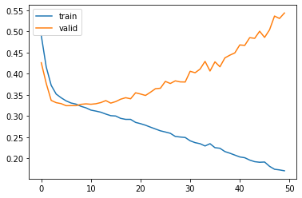

```python
# Capturing learning history per epoch
hist = pd.DataFrame(history.history)
hist["epoch"] = history.epoch

# Plotting accuracy at different epochs
plt.plot(hist["loss"])
plt.plot(hist["val_loss"])
plt.legend(("train", "valid"), loc=0)
```

- From the graph above, it appears the model overfits the train set as the loss on train set was consistently declining while loss function on validation set reduced to a level and started increasing.

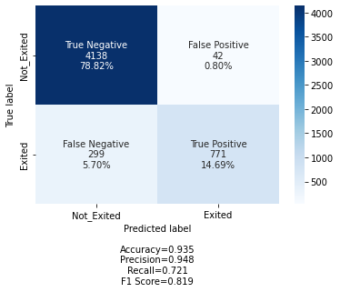

```python
## Confusion Matrix on train set with threshold of 0.5

y_pred1 = model.predict(x_train)
for i in range(len(y_train)):
    if y_pred1[i] > 0.5:
        y_pred1[i] = 1
    else:
        y_pred1[i] = 0


cm2 = confusion_matrix(y_train, y_pred1)
labels = ["True Negative", "False Positive", "False Negative", "True Positive"]
categories = ["Not_Exited", "Exited"]
make_confusion_matrix(cm2, group_names=labels, categories=categories, cmap="Blues")
```

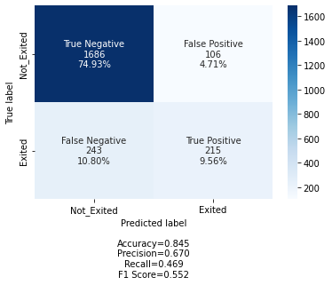

```python
## Confusion Matrix on validation set with threshold of 0.5

y_pred1 = model.predict(x_val)
for i in range(len(y_val)):
    if y_pred1[i] > 0.5:
        y_pred1[i] = 1
    else:
        y_pred1[i] = 0


cm2 = confusion_matrix(y_val, y_pred1)
labels = ["True Negative", "False Positive", "False Negative", "True Positive"]
categories = ["Not_Exited", "Exited"]
make_confusion_matrix(cm2, group_names=labels, categories=categories, cmap="Blues")
```

- With Recall of 0.72 on train set and 0.47 on validation set, it is clear model 1 overfits the train set. We shall explore other models below to reduce this overfitting and get the 243 misclassified exited customers classified correctly.

### Model 2

```python
# Fixing the seed for random number generators so that we can ensure we receive the same output everytime
backend.clear_session()
np.random.seed(42)
random.seed(42)
tf.random.set_seed(42)
```

```python
# This model adds dropout to the hidden layers
model_2 = Sequential()
model_2.add(Dense(units=64, input_dim=13, activation="relu"))
model_2.add(Dense(units=64, activation="relu"))
# Adding Dropout to prevent overfitting
model_2.add(Dropout(0.5))
model_2.add(Dense(32, activation="relu"))
model_2.add(Dropout(0.2))
model_2.add(Dense(32, activation="relu"))
model_2.add(Dense(1, activation="sigmoid"))
```

```python
# Create optimizer with learning rate 0.001
optimizer = Adam(0.001)
model_2.compile(
    optimizer=optimizer, loss="binary_crossentropy", metrics=["Recall"]
)  # Compiling the model
```

```python
# fitting the model
history_2 = model_2.fit(
    x_train, y_train, batch_size=50, epochs=50, validation_data=(x_val, y_val)
)
```

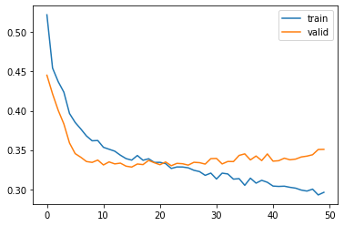

```python
# Capturing learning history per epoch
hist = pd.DataFrame(history_2.history)
hist["epoch"] = history_2.epoch

# Plotting accuracy at different epochs
plt.plot(hist["loss"])
plt.plot(hist["val_loss"])
plt.legend(("train", "valid"), loc=0)
```

- The graph above shows that the dropout added to the model helps to smoothen the loss function of the validation set a bit

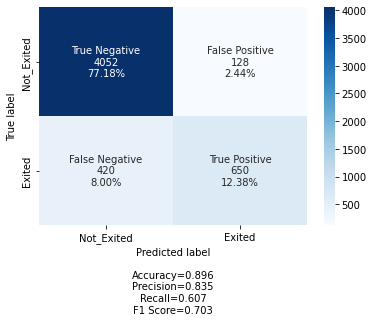

```python
## Confusion Matrix on train set with threshold of 0.5
y_pred2 = model_2.predict(x_train)
for i in range(len(y_train)):
    if y_pred2[i] > 0.5:
        y_pred2[i] = 1
    else:
        y_pred2[i] = 0


cm2_ = confusion_matrix(y_train, y_pred2)
labels = ["True Negative", "False Positive", "False Negative", "True Positive"]
categories = ["Not_Exited", "Exited"]
make_confusion_matrix(cm2_, group_names=labels, categories=categories, cmap="Blues")
```

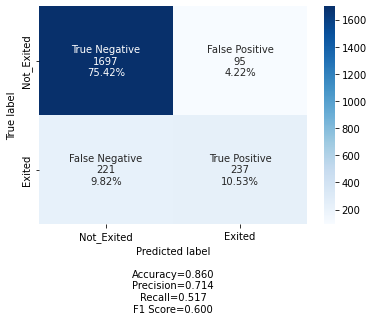

```python
## Confusion Matrix on validation set with threshold of 0.5
y_pred2 = model_2.predict(x_val)
for i in range(len(y_val)):
    if y_pred2[i] > 0.5:
        y_pred2[i] = 1
    else:
        y_pred2[i] = 0


cm2_ = confusion_matrix(y_val, y_pred2)
labels = ["True Negative", "False Positive", "False Negative", "True Positive"]
categories = ["Not_Exited", "Exited"]
make_confusion_matrix(cm2_, group_names=labels, categories=categories, cmap="Blues")
```

- With recall of 0.61 and 0.52 on both train and validation sets respectively, the overfitting reduce but the performance on both sets reduced. 221 customers that would leave the bank are still not correctly identified by the model. Let's see how to get the model performance improved upon.

### Model 3

#### Adding Batch Normalization

```python
# Fixing the seed for random number generators so that we can ensure we receive the same output everytime
backend.clear_session()
np.random.seed(42)
random.seed(42)
tf.random.set_seed(42)
```

```python
# Building model with BatchNormalization
model_3=Sequential()
model_3.add(Dense(units=64, input_dim = 13,activation='relu'))
model_3.add(Dense(units=64,activation='relu'))
#Adding BatchNormalization to prevent overfitting
model_3.add(BatchNormalization())
model_3.add(Dense(32,activation='relu'))
model_3.add(BatchNormalization())
model_3.add(Dense(32,activation='relu'))
model_3.add(BatchNormalization())
model_3.add(Dense(1,activation='sigmoid'))

optimizer=Adam(0.001)
# Compile the model
model_3.compile(optimizer=optimizer,loss='binary_crossentropy',metrics=['Recall'])

history_3 = model_3.fit(x_train, y_train, batch_size=50, validation_data=(x_val, y_val), epochs=50)#fitting the model
```

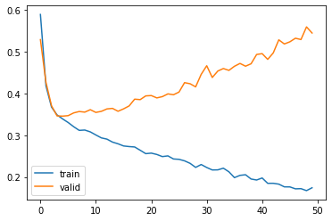

```python
# Capturing learning history per epoch
hist = pd.DataFrame(history_3.history)
hist["epoch"] = history_3.epoch

# Plotting accuracy at different epochs
plt.plot(hist["loss"])
plt.plot(hist["val_loss"])
plt.legend(("train", "valid"), loc=0)
```

- Model_3 still overfits the train set also largely. Let's check the performance in greater details below.

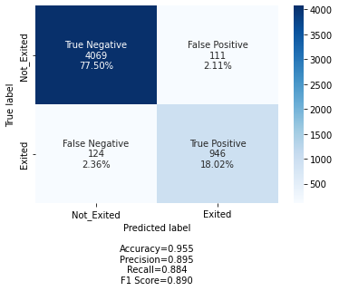

```python
# Confusion matrix on train set with threshold of 0.5
y_pred3 = model_3.predict(x_train)
for i in range(len(y_train)):
    if y_pred3[i] > 0.5:
        y_pred3[i] = 1
    else:
        y_pred3[i] = 0


cm3 = confusion_matrix(y_train, y_pred3)
labels = ["True Negative", "False Positive", "False Negative", "True Positive"]
categories = ["Not_Exited", "Exited"]
make_confusion_matrix(cm3, group_names=labels, categories=categories, cmap="Blues")
```

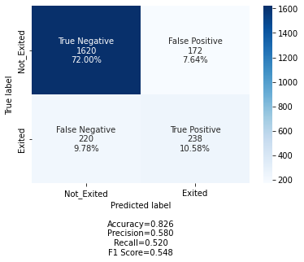

```python
# Confusion matrix on validation set with threshold of 0.5
y_pred3 = model_3.predict(x_val)
for i in range(len(y_val)):
    if y_pred3[i] > 0.5:
        y_pred3[i] = 1
    else:
        y_pred3[i] = 0


cm3 = confusion_matrix(y_val, y_pred3)
labels = ["True Negative", "False Positive", "False Negative", "True Positive"]
categories = ["Not_Exited", "Exited"]
make_confusion_matrix(cm3, group_names=labels, categories=categories, cmap="Blues")
```

- With Recall of 0.88 and 0.52 on train and validation sets respectively, we can see improvement in model_3 performance when compared to Model_2 especially on train set. However, Model_3 still largely overfits the train set. 220 customers that will leave the bank are not identified by the model.
- We shall still carry out some hyperparameters tuning on the model in subsequent model to get improved performance.

### Model 4

```python
# Fixing the seed for random number generators so that we can ensure we receive the same output everytime
backend.clear_session()
np.random.seed(42)
random.seed(42)
tf.random.set_seed(42)
```

```python
# We shall combine dropout and batch normalisation in the hidden layers and tune some other hyperparameters
model_4=Sequential()
model_4.add(Dense(units=64, input_dim = 13,kernel_initializer='he_normal',activation='relu'))   # input of 13 columns and initializing weight with he_normal
model_4.add(Dense(units=64,kernel_initializer='he_normal',activation='relu'))
model_4.add(BatchNormalization())
model_4.add(Dropout(0.5))
model_4.add(Dense(32,kernel_initializer='he_normal',activation='relu'))
model_4.add(BatchNormalization())
model_4.add(Dropout(0.2))
model_4.add(Dense(32,kernel_initializer='he_normal',activation='relu'))
model_4.add(Dense(1,activation='sigmoid'))

optimizer_4 = Adam(0.001) # Create optimizer with learning rate 0.001
# Compiling the model
model_4.compile(optimizer=optimizer_4,loss='binary_crossentropy',metrics=['Recall'])


history_4 = model_4.fit(x_train, y_train, batch_size=50, validation_data=(x_val, y_val), epochs=50) #fitting the model.
```

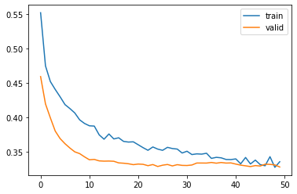

```python
# Capturing learning history per epoch
hist = pd.DataFrame(history_4.history)
hist["epoch"] = history_4.epoch

# Plotting accuracy at different epochs
plt.plot(hist["loss"])
plt.plot(hist["val_loss"])
plt.legend(("train", "valid"), loc=0)
```

- Overfitting has reduced in the model looking at the graph above. However, let's check its performance

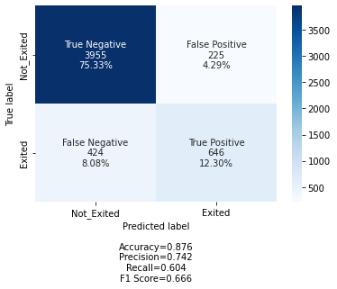

```python
# Confusion Matrix on train set with threshold of 0.5
y_pred4 = model_4.predict(x_train)
for i in range(len(y_train)):
    if y_pred4[i] > 0.5:
        y_pred4[i] = 1
    else:
        y_pred4[i] = 0


cm4 = confusion_matrix(y_train, y_pred4)
labels = ["True Negative", "False Positive", "False Negative", "True Positive"]
categories = ["Not_Exited", "Exited"]
make_confusion_matrix(cm4, group_names=labels, categories=categories, cmap="Blues")
```

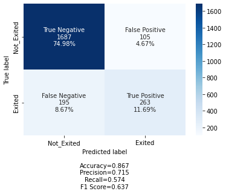

```python
# Confusion Matrix on validation set with threshold of 0.5
y_pred4 = model_4.predict(x_val)
for i in range(len(y_val)):
    if y_pred4[i] > 0.5:
        y_pred4[i] = 1
    else:
        y_pred4[i] = 0


cm4 = confusion_matrix(y_val, y_pred4)
labels = ["True Negative", "False Positive", "False Negative", "True Positive"]
categories = ["Not_Exited", "Exited"]
make_confusion_matrix(cm4, group_names=labels, categories=categories, cmap="Blues")
```

- Recall of 0.60 and 0.57 on both train and validation sets respectively shows that overfitting has reduced but misclassified exited customers(195) are still many. The recall of 0.57 is still the highest so far on the validation set.
- Let's check for optimal threshold as per AUC-ROC curve to see if the model performance will improve.

### Optimal threshold as per AUC-ROC curve

```python
# To find Optimal threshold as per AUC-ROC curve of Model_4 with reduced overfitting and good recall score

fpr, tpr, thresholds = roc_curve(y_train, model_4.predict(x_train))

optimal_idx = np.argmax(tpr - fpr)
optimal_threshold_auc_roc = thresholds[optimal_idx]
print(optimal_threshold_auc_roc)
```

```
0.2141498
```

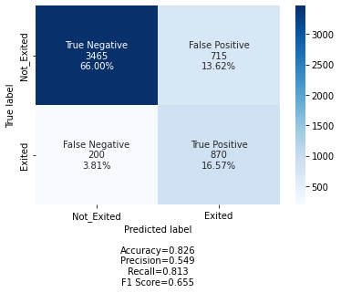

```python
## checking Model_4 performance using the optimal threshold 0.21 gotten

# Confusion Matrix on train set
y_pred4 = model_4.predict(x_train)
for i in range(len(y_train)):
    if y_pred4[i] > 0.21:
        y_pred4[i] = 1
    else:
        y_pred4[i] = 0


cm4a = confusion_matrix(y_train, y_pred4)
labels = ["True Negative", "False Positive", "False Negative", "True Positive"]
categories = ["Not_Exited", "Exited"]
make_confusion_matrix(cm4a, group_names=labels, categories=categories, cmap="Blues")
```

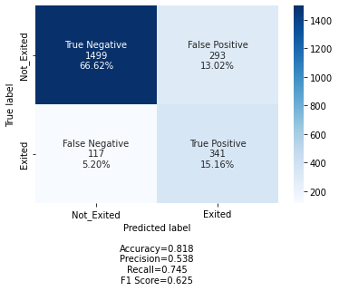

```python
## checking Model_4 performance on validation set using the optimal threshold 0.21 gotten

# Confusion Matrix on validation set
y_pred5 = model_4.predict(x_val)
for i in range(len(y_val)):
    if y_pred5[i] > 0.21:
        y_pred5[i] = 1
    else:
        y_pred5[i] = 0


cm4b = confusion_matrix(y_val, y_pred5)
labels = ["True Negative", "False Positive", "False Negative", "True Positive"]
categories = ["Not_Exited", "Exited"]
make_confusion_matrix(cm4b, group_names=labels, categories=categories, cmap="Blues")
```

- Model_4 predictions with the optimal threshold of 0.21 shows a better performance on both train and validation set. A recall of 0.75 on validation set is still the highest gotten so far. Besides, the misclassified exited customers reduced to 117 in the validation set.
- However, let's carry out some random search among the hyperparameters and see if we can get best combination of parameters that will give better model performance

### Model 5

#### Using Randomized Search for Hyperparameters Tuning

```python
# Fixing the seed for random number generators so that we can ensure we receive the same output everytime
backend.clear_session()
np.random.seed(42)
random.seed(42)
tf.random.set_seed(42)
```

```python
# We are using Random search to optimize two hyperparameters - Batch size & Learning Rate.
def create_model_5(lr, batch_size):
    np.random.seed(1337)
    model = Sequential()
    model.add(Dense(256, activation="relu", input_dim=x_train.shape[1]))
    model.add(Dropout(0.3))
    model.add(Dense(128, activation="relu"))
    model.add(Dropout(0.3))
    model.add(Dense(64, activation="relu"))
    model.add(Dropout(0.2))
    model.add(Dense(32, activation="relu"))
    model.add(Dense(1, activation="sigmoid"))

    # compile model
    optimizer = tf.keras.optimizers.Adam(learning_rate=lr)
    model.compile(optimizer=optimizer, loss="binary_crossentropy", metrics=["accuracy"])
    return model
```

```python
# define the Randomized search parameters
keras_estimator = KerasClassifier(build_fn=create_model_5, verbose=1)

param_random = {
    "batch_size": (30, 100, 10),
    "lr": [0.01, 0.1, 0.001, 0.0001],
}

kfold_splits = 3
random = RandomizedSearchCV(
    estimator=keras_estimator,
    verbose=1,
    cv=kfold_splits,
    param_distributions=param_random,
    n_jobs=-1,
)
```

```python
# Summarize results
random_result = random.fit(x_train, y_train, validation_data=(x_val, y_val), verbose=1)
print("Best: %f using %s" % (random_result.best_score_, random_result.best_params_))
means = random_result.cv_results_["mean_test_score"]
stds = random_result.cv_results_["std_test_score"]
params = random_result.cv_results_["params"]
```

```
Fitting 3 folds for each of 10 candidates, totalling 30 fits
Best: 0.827238 using {'lr': 0.01, 'batch_size': 30}
```

The best model is with the following configuration:

**Result of Random Search**

{'batch_size': 30, 'learning_rate": 0.01}

Let's create the model_5 with the above mentioned configuration

```python
model_5 = create_model_5(
    batch_size=random_result.best_params_["batch_size"],
    lr=random_result.best_params_["lr"],
)

model_5.summary()
```

```
Model: "sequential_1"
_________________________________________________________________
 Layer (type)                Output Shape              Param #
=================================================================
 dense_5 (Dense)             (None, 256)               3584

 dropout_3 (Dropout)         (None, 256)               0

 dense_6 (Dense)             (None, 128)               32896

 dropout_4 (Dropout)         (None, 128)               0

 dense_7 (Dense)             (None, 64)                8256

 dropout_5 (Dropout)         (None, 64)                0

 dense_8 (Dense)             (None, 32)                2080

 dense_9 (Dense)             (None, 1)                 33

=================================================================
Total params: 46,849
Trainable params: 46,849
Non-trainable params: 0
_________________________________________________________________
```

```python
optimizer = tf.keras.optimizers.Adam(random_result.best_params_["lr"])
model_5.compile(loss="binary_crossentropy", optimizer=optimizer, metrics=["Recall"])
history_5 = model_5.fit(
    x_train,
    y_train,
    epochs=50,
    batch_size=30,
    verbose=1,
    validation_data=(x_val, y_val),
)
```

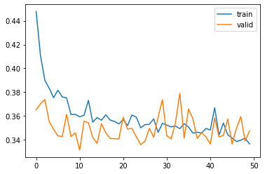

```python
# Capturing learning history per epoch
hist5 = pd.DataFrame(history_5.history)
hist5["epoch"] = history_5.epoch

# Plotting accuracy at different epochs
plt.plot(hist5["loss"])
plt.plot(hist5["val_loss"])
plt.legend(("train", "valid"), loc=0)
```

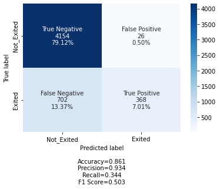

```python
## checking Model_5 performance on train set

# Confusion Matrix on train set
y_pred5 = model_5.predict(x_train)
for i in range(len(y_train)):
    if y_pred5[i] > 0.5:
        y_pred5[i] = 1
    else:
        y_pred5[i] = 0


cm5a = confusion_matrix(y_train, y_pred5)
labels = ["True Negative", "False Positive", "False Negative", "True Positive"]
categories = ["Not_Exited", "Exited"]
make_confusion_matrix(cm5a, group_names=labels, categories=categories, cmap="Blues")
```

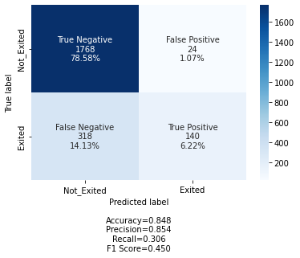

```python
## checking Model_5 performance on validation set

# Confusion Matrix on validation set
y_pred5 = model_5.predict(x_val)
for i in range(len(y_val)):
    if y_pred5[i] > 0.5:
        y_pred5[i] = 1
    else:
        y_pred5[i] = 0


cm5b = confusion_matrix(y_val, y_pred5)
labels = ["True Negative", "False Positive", "False Negative", "True Positive"]
categories = ["Not_Exited", "Exited"]
make_confusion_matrix(cm5b, group_names=labels, categories=categories, cmap="Blues")
```

- With recall of 0.34 and 0.31 on train and validation set respectively, Model_5 shows worse performance than the previous models.

### Model 6

#### Oversampling the imbalanced data

```python
# Let's build another model on oversampled data

# Applying SMOTE on train set
smote = SMOTE(sampling_strategy="not majority")
x_sm, y_sm = smote.fit_resample(x_train, y_train)
```

```python
# Fixing the seed for random number generators so that we can ensure we receive the same output everytime
backend.clear_session()
np.random.seed(42)
tf.random.set_seed(42)
```

```python
# We shall build another model on oversampled data
model_6=Sequential()
model_6.add(Dense(units=64, input_dim = 13,kernel_initializer='he_normal',activation='relu'))   # input of 13 columns and initializing weight with he_normal
model_6.add(Dense(units=64,kernel_initializer='he_normal',activation='relu'))
model_6.add(BatchNormalization())
model_6.add(Dropout(0.5))
model_6.add(Dense(32,kernel_initializer='he_normal',activation='relu'))
model_6.add(BatchNormalization())
model_6.add(Dropout(0.2))
model_6.add(Dense(32,kernel_initializer='he_normal',activation='relu'))
model_6.add(Dense(1,activation='sigmoid'))

optimizer_6 = Adam(0.001) # Create optimizer with learning rate 0.001
# Compiling the model
model_6.compile(optimizer=optimizer_6,loss='binary_crossentropy',metrics=['Recall'])


history_6 = model_6.fit(x_sm, y_sm, batch_size=50, validation_data=(x_val, y_val), epochs=50) #fitting the model on oversampled data.
```

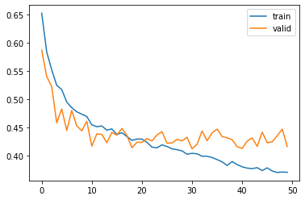

```python
# Capturing learning history per epoch
hist6 = pd.DataFrame(history_6.history)
hist6["epoch"] = history_6.epoch

# Plotting accuracy at different epochs
plt.plot(hist6["loss"])
plt.plot(hist6["val_loss"])
plt.legend(("train", "valid"), loc=0)
```

- The curves are a bit smooth but some overfitting can still be noticed in the train set

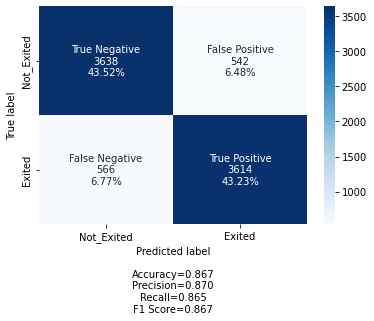

```python
## checking Model_6 performance on train set

# Confusion Matrix on validation set
y_pred6 = model_6.predict(x_sm)
for i in range(len(y_sm)):
    if y_pred6[i] > 0.5:
        y_pred6[i] = 1
    else:
        y_pred6[i] = 0


cm6 = confusion_matrix(y_sm, y_pred6)
labels = ["True Negative", "False Positive", "False Negative", "True Positive"]
categories = ["Not_Exited", "Exited"]
make_confusion_matrix(cm6, group_names=labels, categories=categories, cmap="Blues")
```

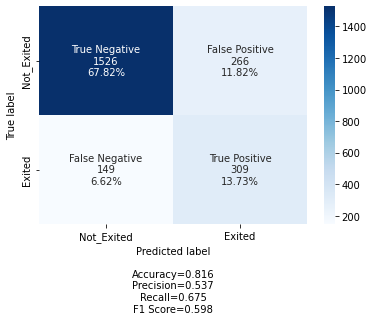

```python
## checking Model_6 performance on validation set

# Confusion Matrix on validation set
y_pred6 = model_6.predict(x_val)
for i in range(len(y_val)):
    if y_pred6[i] > 0.5:
        y_pred6[i] = 1
    else:
        y_pred6[i] = 0


cm6 = confusion_matrix(y_val, y_pred6)
labels = ["True Negative", "False Positive", "False Negative", "True Positive"]
categories = ["Not_Exited", "Exited"]
make_confusion_matrix(cm6, group_names=labels, categories=categories, cmap="Blues")
```

- A recall of 0.87 and 0.68 on oversampled train set and validation set respectively shows that model 6 is still overfitting the train set and the performance is still slightly below the Model_4 with optimal threshold on the validation set.
- Let's find optimal threshold of Model 6 using AUC-ROC Curve and check the performance on validation set

```python
# To find Optimal threshold as per AUC-ROC curve of Model_6 with reduced overfitting and good recall score

fpr, tpr, thresholds = roc_curve(y_sm, model_6.predict(x_sm))

optimal_idx = np.argmax(tpr - fpr)
optimal_threshold_auc_roc = thresholds[optimal_idx]
print(optimal_threshold_auc_roc)
```

```
0.41816193
```

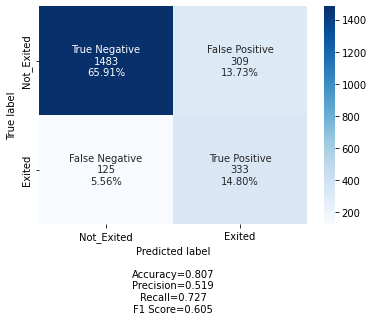

```python
## checking Model_6 performance on validation set with optimal threhold of  0.41816193

# Confusion Matrix on validation set
y_pred6 = model_6.predict(x_val)
for i in range(len(y_val)):
    if y_pred6[i] > 0.41816193:
        y_pred6[i] = 1
    else:
        y_pred6[i] = 0


cm6 = confusion_matrix(y_val, y_pred6)
labels = ["True Negative", "False Positive", "False Negative", "True Positive"]
categories = ["Not_Exited", "Exited"]
make_confusion_matrix(cm6, group_names=labels, categories=categories, cmap="Blues")
```

- The recall of 0.73 on validation set above is an improvement on the earlier 0.68 gotten with threshold 0.5.
- We shall explore undersampling the data to check for improved model performance

### Model 7

### Using undersampling techniques

```python
# Undersampling the train set
rus = RandomUnderSampler(random_state=1)
x_train_un, y_train_un = rus.fit_resample(x_train, y_train)
```

```python
# Fixing the seed for random number generators so that we can ensure we receive the same output everytime
backend.clear_session()
np.random.seed(42)
tf.random.set_seed(42)
```

```python
# We shall build another model on oversampled data
model_7=Sequential()
model_7.add(Dense(units=64, input_dim = 13,kernel_initializer='he_normal',activation='relu'))   # input of 13 columns and initializing weight with he_normal
model_7.add(Dense(units=64,kernel_initializer='he_normal',activation='relu'))
model_7.add(BatchNormalization())
model_7.add(Dropout(0.5))
model_7.add(Dense(32,kernel_initializer='he_normal',activation='relu'))
model_7.add(BatchNormalization())
model_7.add(Dropout(0.2))
model_7.add(Dense(32,kernel_initializer='he_normal',activation='relu'))
model_7.add(Dense(1,activation='sigmoid'))

optimizer_7 = Adam(0.001) # Create optimizer with learning rate 0.001
# Compiling the model
model_7.compile(optimizer=optimizer_7,loss='binary_crossentropy',metrics=['Recall'])


history_7 = model_7.fit(x_train_un, y_train_un, batch_size=50, validation_data=(x_val, y_val), epochs=50) #fitting the model on oversampled data.
```

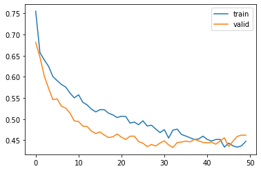

```python
# Capturing learning history per epoch
hist7 = pd.DataFrame(history_7.history)
hist7["epoch"] = history_7.epoch

# Plotting accuracy at different epochs
plt.plot(hist7["loss"])
plt.plot(hist7["val_loss"])
plt.legend(("train", "valid"), loc=0)
```

- The curves are smooth and overfitting has reduced in the train set. Let's check the model performance in full below

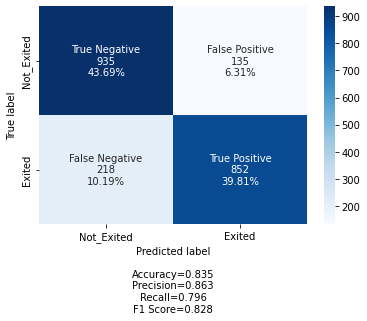

```python
## checking Model_7 performance on train set

# Confusion Matrix on validation set
y_pred7 = model_7.predict(x_train_un)
for i in range(len(y_train_un)):
    if y_pred7[i] > 0.5:
        y_pred7[i] = 1
    else:
        y_pred7[i] = 0


cm7 = confusion_matrix(y_train_un, y_pred7)
labels = ["True Negative", "False Positive", "False Negative", "True Positive"]
categories = ["Not_Exited", "Exited"]
make_confusion_matrix(cm7, group_names=labels, categories=categories, cmap="Blues")
```

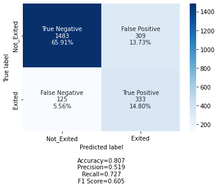

```python
## checking Model_7 performance on validation set

# Confusion Matrix on validation set
y_pred8 = model_7.predict(x_val)
for i in range(len(y_val)):
    if y_pred8[i] > 0.5:
        y_pred8[i] = 1
    else:
        y_pred8[i] = 0


cm8 = confusion_matrix(y_val, y_pred8)
labels = ["True Negative", "False Positive", "False Negative", "True Positive"]
categories = ["Not_Exited", "Exited"]
make_confusion_matrix(cm6, group_names=labels, categories=categories, cmap="Blues")
```

```python
# To find Optimal threshold as per AUC-ROC curve of Model_7 with reduced overfitting and good recall score

fpr, tpr, thresholds = roc_curve(y_train_un, model_7.predict(x_train_un))

optimal_idx = np.argmax(tpr - fpr)
optimal_threshold_auc_roc = thresholds[optimal_idx]
print(optimal_threshold_auc_roc)
```

```
0.40029845
```

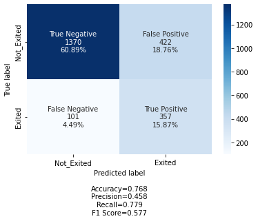

```python
## checking Model_7 performance on validation set with optimal threshold of 0.4

# Confusion Matrix on validation set
y_pred9 = model_7.predict(x_val)
for i in range(len(y_val)):
    if y_pred9[i] > 0.40:
        y_pred9[i] = 1
    else:
        y_pred9[i] = 0


cm9 = confusion_matrix(y_val, y_pred9)
labels = ["True Negative", "False Positive", "False Negative", "True Positive"]
categories = ["Not_Exited", "Exited"]
make_confusion_matrix(cm9, group_names=labels, categories=categories, cmap="Blues")
```

- Model_7 with optimal threshold of 0.40 has given us the highest recall so far in the project which is approximately 0.78. We will check its performance on the test set as well

### Checking Model 7 with optimal threshold performance on test set

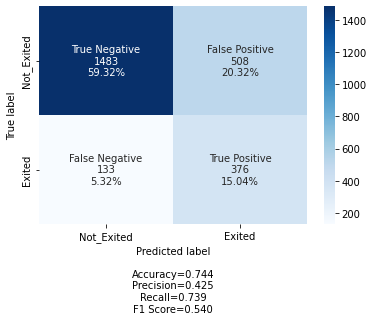

```python
# Confusion Matrix on test set
y_pred10 = model_7.predict(x_test)
for i in range(len(y_test)):
    if y_pred10[i] > 0.40:
        y_pred10[i] = 1
    else:
        y_pred10[i] = 0


cm10 = confusion_matrix(y_test, y_pred10)
labels = ["True Negative", "False Positive", "False Negative", "True Positive"]
categories = ["Not_Exited", "Exited"]
make_confusion_matrix(cm10, group_names=labels, categories=categories, cmap="Blues")
```

- A recall of 0.74 was achieved on the test set, although with accuracy of 0.74 and precision of 0.43. However, the model is able to reduce the misclassified exited customers to the 133 on unseen data.